# Problem5

Question 5 - The data below represents the number of chairs in each class of a government high school. Create a box plot and swarm plot (add jitter) and find the number of data points that are outliers. 35, 54, 60, 65, 66, 67, 69, 70, 72, 73, 75, 76, 54, 25, 15, 60, 65, 66, 67, 69, 70, 72, 130, 73, 75, 76

```python
from matplotlib import pyplot as plt
import numpy as np
import seaborn as sns
import pandas as pd
```

```python
chairs = [35, 54, 60, 65, 66, 67, 69, 70, 72, 73, 75, 76, 54, 25, 15, 60, 65, 66, 67, 69, 70, 72, 130, 73, 75, 75]
```

```python
df = pd.DataFrame(chairs, columns =  ['chairs'])
```

In descriptive statistics, a box plot or boxplot is a method for graphically demonstrating the locality, spread and skewness groups of numerical data through their quartiles. In addition to the box on a box plot, there can be lines (which are called whiskers) extending from the box indicating variability outside the upper and lower quartiles, thus, the plot is also termed as the box-and-whisker plot and the box-and-whisker diagram. Outliers that differ significantly from the rest of the dataset may be plotted as individual points beyond the whiskers on the box-plot. Box plots are non-parametric: they display variation in samples of a statistical population without making any assumptions of the underlying statistical distribution (though Tukey's boxplot assumes symmetry for the whiskers and normality for their length). The spacings in each subsection of the box-plot indicate the degree of dispersion (spread) and skewness of the data, which are usually described using the five-number summary. In addition, the box-plot allows one to visually estimate various L-estimators, notably the interquartile range, midhinge, range, mid-range, and trimean. Box plots can be drawn either horizontally or vertically.

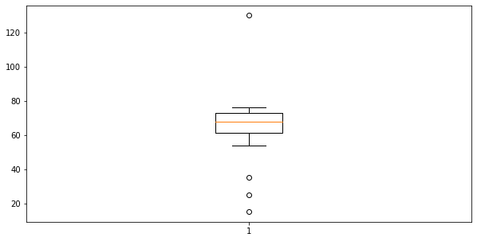

```python
fig = plt.figure(figsize=(10, 5))
plt.boxplot(chairs)
plt.show()
```

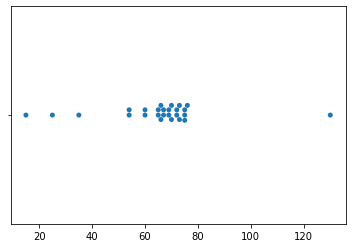

```python
sns.swarmplot(x=chairs)
```

Boxplot and swarmplot together with added jitter will look like the following

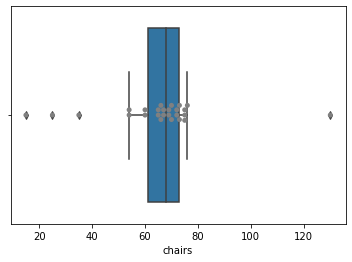

```python
ax = sns.boxplot(x='chairs', data=df)
ax = sns.swarmplot(x='chairs', data=df, color="grey")
plt.show()
```

As we can see clearly from the boxplot above, the number of outliers in the given data are 4, 3 outliers in the first quartile and 1 outlier lies in the third quartile.